# Verifying sample relationships using genotypes or inferred genotypes

Maarten van Iterson and Davy Cats

Department of Medical Statistics and Bioinformatics, Section Moleculair Epidemiology, Leiden University Medical Center

mviterson@gmail.com  
davycats.dc@gmail.com

2017-10-12

#### Abstract

Analysis of multiple omics datatypes from the same individuals is becoming increasingly common. For example, several data repositories contain genetic, transcriptomic and epigenetic (DNA methylation) measurements on the same individuals, e.g. TCGA, Geuvadis, BBMRI/BIOS, etc. We have developed a tool that can verify the sample relationships between and across omics types. A small number of misspecified samples can destroy analyses for example assuming an analysis on unrelated individuals whereas parent offspring relations exist.

#### Package

omicsPrint 0.99.14

Here we illustrate the use of the package using artificially generated data and provide an example of usage with experimental data. A few other vignettes are available that show the use of the package on experimental data, i.e. 450k DNA methylation, RNAsequencing data and imputed genotypes.

# 1 Within omics sample relationship verification

## 1.1 Create toy data

Here we generate a single vector with 100 randomly drawn integers from the set; 1, 2, 3, representing 100 SNP calls from a single individual. Three other samples are generated from this one by randomly swapping a certain fraction of the SNPs. For example, swapping only 5 SNPs only introduces some noise but should still reflect the same individual. However, swapping 50% of the SNPs is similar to the difference in genotypes between parents and offspring. Swapping all SNPs will result in a unrelated individual.

```r
swap <- function(x, frac=0.05) {
    n <- length(x)
    k <- floor(n*frac)
    x1 <- sample(1:n,k)
    x2 <- sample(1:n,k) ##could be overlapping
    x[x2] <- x[x1]
    x
}
x1 <- 1 + rbinom(100, size=2, prob=1/3)
x2 <- swap(x1, 0.05) ##strongly related e.g. replicate
x3 <- swap(x1, 0.5) ##related e.g. parent off spring
x4 <- swap(x1, 1) ##unrelated
x <- cbind(x1, x2, x3, x4)
head(x)
```

```
##      x1 x2 x3 x4
## [1,]  1  1  1  2
## [2,]  2  2  2  3
## [3,]  1  1  2  2
## [4,]  1  1  1  3
## [5,]  1  1  1  2
## [6,]  2  2  2  1
```

## 1.2 Running the `allelesharing` algorithm

We use Identity by State (IBS) for a set of SNPs to infer sample relations. See Abecasis et al. (2001), for the description of this approach applied to genetic data. Briefly, between each sample pair the identity by state vector is calculated, which is a measure of genetic distance between individuals. Next the vector is summarized by its mean and variance. A mean of 2 and variance of 0 indicates that the samples are identical.

```r
library(omicsPrint)
data <- alleleSharing(x)
```

```
## Hash relations
```

```
## There are 0 SNP dropped because of low call rate!
```

```
## There are 0 sample set to NA because too little SNPs called!
```

```
## Using 100 polymorphic SNPs to determine allele sharing.
```

```
## Running `square` IBS algorithm!
```

```
## 5 of 10 (50%) ...
```

```r
data
```

```
##    mean        var colnames.x colnames.y  relation
## 1  2.00 0.00000000         x1         x1 identical
## 2  1.98 0.01979798         x2         x1 unrelated
## 3  1.70 0.23232323         x3         x1 unrelated
## 4  1.34 0.38828283         x4         x1 unrelated
## 5  2.00 0.00000000         x2         x2 identical
## 6  1.68 0.24000000         x3         x2 unrelated
## 7  1.34 0.38828283         x4         x2 unrelated
## 8  2.00 0.00000000         x3         x3 identical
## 9  1.34 0.36808081         x4         x3 unrelated
## 10 2.00 0.00000000         x4         x4 identical
```

By default no relations are assumed only the self-self relations. Genotype calls can contain NA’s, e.g. not measured in all samples or bad quality. Some pruning is performed to remove really bad cases.

The output is a `data.frame` containing all pairwise comparisons with the mean and variance of the IBS over the set of SNPs and the reported sample relationship, including the identifiers.

## 1.3 Report mismatches and provide graphical summary

Since, we provided a list of known relations, assuming the majority is correct, we can build a classifier to discover missclassified relations. The current implementation uses linear discriminant analysis and generates a confusion-matrix, graphically representation of the classification boundaries and outputs the missclassified sample pairs.

```r
mismatches <- inferRelations(data)
```

```
##                   Assumed relation
## Predicted relation identical unrelated
##          identical         4         1
##          unrelated         .         5
```

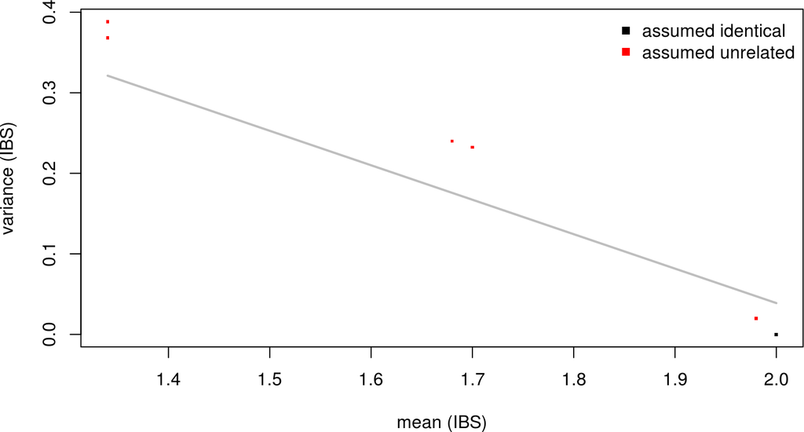

Figure 1: Scatter-plot of IBS mean and variance with classification boundary  
For pairwise comparison between the samples without specifying sample relationships.

```r
mismatches
```

```
##   mean        var colnames.x colnames.y  relation predicted
## 2 1.98 0.01979798         x2         x1 unrelated identical
```

Indeed, there is one misclassified sample, the replicate that we introduced. The true relationship with between `x1` and `x2` is an identical relation. Furthermore, we see two sample pairs with mean IBS of 1.7 and variance 0.2 which is an indication that also these pairs share a considerable number of alleles. In such, cases we should provide the known relations in a `data.frame` and specify the relation types.

```r
relations <- expand.grid(idx = colnames(x), idy= colnames(x))
relations$relation_type <- "unrelated"
relations$relation_type[relations$idx == relations$idy] <- "identical"
relations$relation_type[c(2,5)] <- "identical" ##replicate
relations$relation_type[c(3,7,9,10)] <- "parent offspring"
relations
```

```
##    idx idy    relation_type
## 1   x1  x1        identical
## 2   x2  x1        identical
## 3   x3  x1 parent offspring
## 4   x4  x1        unrelated
## 5   x1  x2        identical
## 6   x2  x2        identical
## 7   x3  x2 parent offspring
## 8   x4  x2        unrelated
## 9   x1  x3 parent offspring
## 10  x2  x3 parent offspring
## 11  x3  x3        identical
## 12  x4  x3        unrelated
## 13  x1  x4        unrelated
## 14  x2  x4        unrelated
## 15  x3  x4        unrelated
## 16  x4  x4        identical
```

Rerun the allelesharing algorithm now provided with the known relations.

```r
data <- alleleSharing(x, relations=relations)
```

```
## Hash relations
```

```
## There are 0 SNP dropped because of low call rate!
```

```
## There are 0 sample set to NA because too little SNPs called!
```

```
## Using 100 polymorphic SNPs to determine allele sharing.
```

```
## Running `square` IBS algorithm!
```

```
## 5 of 10 (50%) ...
```

```r
data
```

```
##    mean        var colnames.x colnames.y         relation
## 1  2.00 0.00000000         x1         x1        identical
## 2  1.98 0.01979798         x2         x1        identical
## 3  1.70 0.23232323         x3         x1 parent offspring
## 4  1.34 0.38828283         x4         x1        unrelated
## 5  2.00 0.00000000         x2         x2        identical
## 6  1.68 0.24000000         x3         x2 parent offspring
## 7  1.34 0.38828283         x4         x2        unrelated
## 8  2.00 0.00000000         x3         x3        identical
## 9  1.34 0.36808081         x4         x3        unrelated
## 10 2.00 0.00000000         x4         x4        identical
```

```r
mismatches <- inferRelations(data)
```

```
##                   Assumed relation
## Predicted relation identical parent offspring unrelated
##   identical                5                .         .
##   parent offspring         .                2         .
##   unrelated                .                .         3
```

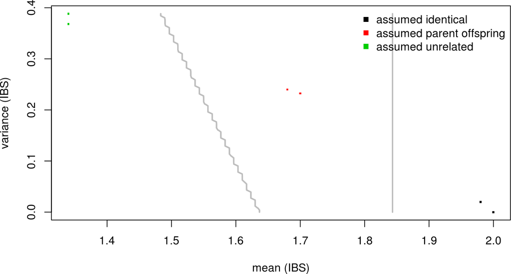

Figure 2: Scatter-plot of IBS mean and variance with classification boundaries  
For pairwise comparison between the samples with specifying sample relationships.

```r
mismatches
```

```
## [1] mean       var        colnames.x colnames.y relation   predicted
## <0 rows> (or 0-length row.names)
```

Now there are no misclassified sample relations.

# 2 Across omics sample relationship verification

The previous example showed how to perform sample relationship verification within an omics data type. If a second set of overlapping SNPs is available, obtained from a different omic type, for the same or related individuals sample relationshi verification can be run between these two.

```r
rownames(x) <- paste0("rs", 1:100)
y <- x[sample(1:100, 80),]
data <- alleleSharing(x, y)
```

```
## Hash relations
```

```
## There are 0 SNP dropped because of low call rate!
```

```
## There are 0 sample set to NA because too little SNPs called!
```

```
## There are 0 SNP dropped because of low call rate!
```

```
## There are 0 sample set to NA because too little SNPs called!
```

```
## Using 80 polymophic SNPs to determine allele sharing.
```

```
## Running `rectangular` IBS algorithm!
```

```
## 4 of 16 (25%) ...
```

```r
data
```

```
##      mean        var colnames.x colnames.y  relation
## 1  2.0000 0.00000000         x1         x1 identical
## 2  1.9750 0.02468354         x2         x1 unrelated
## 3  1.7125 0.23275316         x3         x1 unrelated
## 4  1.3500 0.38227848         x4         x1 unrelated
## 5  1.9750 0.02468354         x1         x2 unrelated
## 6  2.0000 0.00000000         x2         x2 identical
## 7  1.6875 0.24287975         x3         x2 unrelated
## 8  1.3500 0.38227848         x4         x2 unrelated
## 9  1.7125 0.23275316         x1         x3 unrelated
## 10 1.6875 0.24287975         x2         x3 unrelated
## 11 2.0000 0.00000000         x3         x3 identical
## 12 1.3625 0.36060127         x4         x3 unrelated
## 13 1.3500 0.38227848         x1         x4 unrelated
## 14 1.3500 0.38227848         x2         x4 unrelated
## 15 1.3625 0.36060127         x3         x4 unrelated
## 16 2.0000 0.00000000         x4         x4 identical
```

```r
mismatches <- inferRelations(data)
```

```
##                   Assumed relation
## Predicted relation identical unrelated
##          identical         4         2
##          unrelated         .        10
```

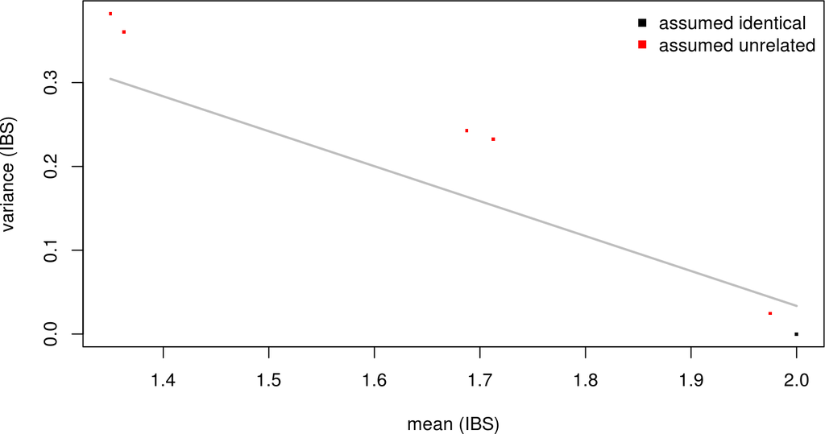

Figure 3: Scatter-plot of IBS mean and variance with classification boundary  
For pairwise comparison between the samples without specifying sample relationships.

```r
mismatches
```

```
##    mean        var colnames.x colnames.y  relation predicted
## 2 1.975 0.02468354         x2         x1 unrelated identical
## 5 1.975 0.02468354         x1         x2 unrelated identical
```

Notice pruning is performed on both data types and automatically the overlapping set of SNPs (80) is used, provided that the rownames between `x` and `y` are the same (Note also this holds for providing relations where the relation identifiers `idx` and `idy` should match with the columnames of `x` and `y`).

```r
data <- alleleSharing(x, y, relations)
```

```
## Hash relations
```

```
## There are 0 SNP dropped because of low call rate!
```

```
## There are 0 sample set to NA because too little SNPs called!
```

```
## There are 0 SNP dropped because of low call rate!
```

```
## There are 0 sample set to NA because too little SNPs called!
```

```
## Using 80 polymophic SNPs to determine allele sharing.
```

```
## Running `rectangular` IBS algorithm!
```

```
## 4 of 16 (25%) ...
```

```r
data
```

```
##      mean        var colnames.x colnames.y         relation
## 1  2.0000 0.00000000         x1         x1        identical
## 2  1.9750 0.02468354         x2         x1        identical
## 3  1.7125 0.23275316         x3         x1 parent offspring
## 4  1.3500 0.38227848         x4         x1        unrelated
## 5  1.9750 0.02468354         x1         x2        identical
## 6  2.0000 0.00000000         x2         x2        identical
## 7  1.6875 0.24287975         x3         x2 parent offspring
## 8  1.3500 0.38227848         x4         x2        unrelated
## 9  1.7125 0.23275316         x1         x3 parent offspring
## 10 1.6875 0.24287975         x2         x3 parent offspring
## 11 2.0000 0.00000000         x3         x3        identical
## 12 1.3625 0.36060127         x4         x3        unrelated
## 13 1.3500 0.38227848         x1         x4        unrelated
## 14 1.3500 0.38227848         x2         x4        unrelated
## 15 1.3625 0.36060127         x3         x4        unrelated
## 16 2.0000 0.00000000         x4         x4        identical
```

```r
mismatches <- inferRelations(data)
```

```
##                   Assumed relation
## Predicted relation identical parent offspring unrelated
##   identical                6                .         .
##   parent offspring         .                4         .
##   unrelated                .                .         6
```

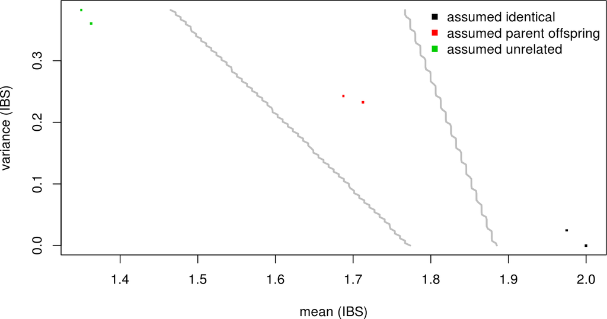

Figure 4: Scatter-plot of IBS mean and variance with classification boundaries  
For pairwise comparison between the samples with specifying sample relationships.

```r
mismatches
```

```
## [1] mean       var        colnames.x colnames.y relation   predicted
## <0 rows> (or 0-length row.names)
```

Again providing the known and true relationships yield no missclassified sample relationships.

# 3 An example using real world methylation data from a `SummarizedExperiment`

Let’s start by cleaning up the workspace:

```r
rm(list=ls())
```

Now we extract the data from GEO using the [*GEOquery*](http://bioconductor.org/packages/GEOquery/)-package and convert the returned object into a [*SummarizedExperiment*](http://bioconductor.org/packages/SummarizedExperiment/):

```r
library(GEOquery)
library(SummarizedExperiment)
gset <- getGEO("GSE39672", GSEMatrix=TRUE)
```

```
## https://ftp.ncbi.nlm.nih.gov/geo/series/GSE39nnn/GSE39672/matrix/
```

```
## OK
```

```
## Found 1 file(s)
```

```
## GSE39672_series_matrix.txt.gz
```

```
## File stored at:
```

```
## /tmp/Rtmp6HYSHH/GPL13534.soft
```

```r
se <- SummarizedExperiment(assays = list(betas=exprs(gset[[1]])),
                           colData=pData(gset[[1]]),
                           rowData=fData(gset[[1]]))
se
```

```
## class: SummarizedExperiment
## dim: 485577 133
## metadata(0):
## assays(1): betas
## rownames(485577): cg00000029 cg00000108 ... rs966367 rs9839873
## rowData names(37): ID Name ... RANGE_GB SPOT_ID
## colnames(133): GSM977267 GSM977268 ... GSM977398 GSM977399
## colData names(37): title geo_accession ... supplementary_file
##   data_row_count
```

Sample data can be extracted from the `SummarizedExperiment`-object using the `colData`-function:

```r
names(colData(se))
```

```
##  [1] "title"                    "geo_accession"
##  [3] "status"                   "submission_date"
##  [5] "last_update_date"         "type"
##  [7] "channel_count"            "source_name_ch1"
##  [9] "organism_ch1"             "characteristics_ch1"
## [11] "characteristics_ch1.1"    "characteristics_ch1.2"
## [13] "biomaterial_provider_ch1" "growth_protocol_ch1"
## [15] "molecule_ch1"             "extract_protocol_ch1"
## [17] "label_ch1"                "label_protocol_ch1"
## [19] "taxid_ch1"                "hyb_protocol"
## [21] "scan_protocol"            "description"
## [23] "data_processing"          "platform_id"
## [25] "contact_name"             "contact_email"
## [27] "contact_phone"            "contact_laboratory"
## [29] "contact_department"       "contact_institute"
## [31] "contact_address"          "contact_city"
## [33] "contact_state"            "contact_zip/postal_code"
## [35] "contact_country"          "supplementary_file"
## [37] "data_row_count"
```

```r
colData(se)[1,c("title", "geo_accession", "type")]
```

```
## DataFrame with 1 row and 3 columns
##                                          title geo_accession     type
##                                       <factor>      <factor> <factor>
## GSM977267 HapMap Cytosine Modification NA19147     GSM977267  genomic
```

```r
population <- colData(se)["characteristics_ch1"]
table(population)
```

```
##
## panel: CEU panel: YRI
##         60         73
```

If we would have had the raw idats we could extract the 65 SNPs. However, experience shows that the 65 SNPs available on the array are not enough to perform sample verification with high confidence. Fortunately, several probes on the array contain SNPs occurring frequently in different populations(Chen et al. 2013; Zhou, Laird, and Shen 2016).

We have made the data available from inside of this package package.

Now we make a selection of CpGs probably affected by polymorphic SNPS in these two populations:

```r
data(hm450.manifest.pop.GoNL)
cpgs <- names(hm450.manifest.pop.GoNL[
    mcols(hm450.manifest.pop.GoNL)$MASK.snp5.CEU |
    mcols(hm450.manifest.pop.GoNL)$MASK.snp5.YRI])
se <- se[cpgs,]
```

Next the beta-values are converted to genotypes using our enhanced K-means algorithm:

```r
dnamCalls <- beta2genotype(se, assayName = "betas")
dim(dnamCalls)
```

```
## [1] 1060  133
```

```r
dnamCalls[1:5, 1:5]
```

```
##            GSM977267 GSM977268 GSM977269 GSM977270 GSM977271
## cg06624358         1         1         1         1         3
## cg13917577         1         3         1         3         2
## cg11853970         3         3         3         3         3
## cg04891761         2         1         1         3         2
## cg25619287         3         3         1         3         3
```

The DNA methylation based genotype calls can be directly supplied to the allelesharing algorithm to perform the intra-omic sample matching:

```r
data <- alleleSharing(dnamCalls)
```

```
## Hash relations
```

```
## There are 0 SNP dropped because of low call rate!
```

```
## There are 0 sample set to NA because too little SNPs called!
```

```
## Using 1060 polymorphic SNPs to determine allele sharing.
```

```
## Running `square` IBS algorithm!
```

```
## 134 of 8911 (1.5%) ...
```

```
## 8351 of 8911 (93.72%) ...
```

```r
mismatches <- inferRelations(data)
```

```
##                   Assumed relation
## Predicted relation identical unrelated
##          identical       133         .
##          unrelated         .      8778
```

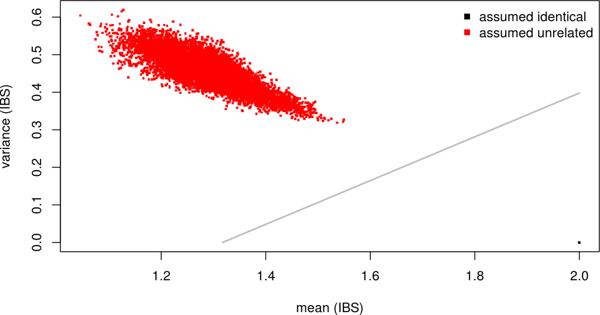

```r
nrow(data) ##number of pairs
```

```
## [1] 8911
```

```r
ncol(dnamCalls) ##identical
```

```
## [1] 133
```

```r
ncol(dnamCalls)*(ncol(dnamCalls) - 1)/2 ##non-identical
```

```
## [1] 8778
```

```r
ncol(dnamCalls)*(ncol(dnamCalls) + 1)/2 ##total
```

```
## [1] 8911
```

There are no unknown relations in the data, verifying Moen et al. (2013), as all samples should be unrelated.

> NOTE: the number just represent the number of diagonal elements, off-diagonal (upper or lower) and diagonal + off-diagonal (upper/lower) of the square matrix with sample identifiers.

# Reference

Abecasis, G. R., S. S. Cherny, W. O. Cookson, and L. R. Cardon. 2001. “GRR: graphical representation of relationship errors.” *Bioinformatics* 17 (8): 742–43.

Chen, Y. A., M. Lemire, S. Choufani, D. T. Butcher, D. Grafodatskaya, B. W. Zanke, S. Gallinger, T. J. Hudson, and R. Weksberg. 2013. “Discovery of cross-reactive probes and polymorphic CpGs in the Illumina Infinium HumanMethylation450 microarray.” *Epigenetics* 8 (2): 203–9.

Moen, E. L., X. Zhang, W. Mu, S. M. Delaney, C. Wing, J. McQuade, J. Myers, L. A. Godley, M. E. Dolan, and W. Zhang. 2013. “Genome-wide variation of cytosine modifications between European and African populations and the implications for complex traits.” *Genetics* 194 (4): 987–96.

Zhou, W., P. W. Laird, and H. Shen. 2016. “Comprehensive characterization, annotation and innovative use of Infinium DNA methylation BeadChip probes.” *Nucleic Acids Res.*, October.